# 選舉民調準嗎？

To do: 1.Change regressions into charts 2.Do a bump chart for the rank changes in different specification

## Sample Selection

```r
dt[,.N] # Number of Election-Candidate Count
```

```
## [1] 1924
```

```r
length(unique(dt$Institute)) # Number of unique institute
```

```
## [1] 57
```

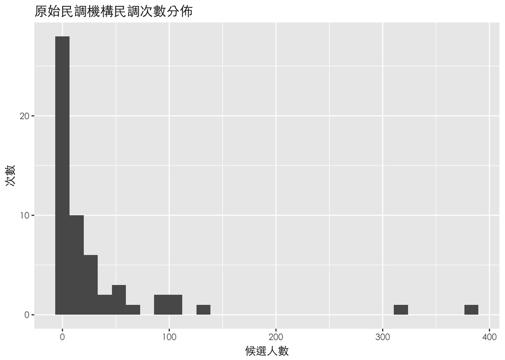

```r
dt[,Institute := as.factor(Institute)]
dtInstituteCount <- dt[,list(N = .N,noElection = length(unique(Election))), by = Institute]
ggplot(dtInstituteCount, aes(x=N)) +
  theme(text = element_text(family = "Heiti TC Light")) +
  geom_histogram() + xlab("候選人數") + ylab("次數") +
  ggtitle("原始民調機構民調次數分佈")
```

前 15 大民調機構如下：

```r
setorder(dtInstituteCount,-N)
pander(dtInstituteCount[1:15,])
```

| Institute | N | noElection |
| --- | --- | --- |
| 中國時報 | 384 | 5 |
| TVBS | 314 | 5 |
| 聯合報 | 137 | 5 |
| 自由時報 | 107 | 5 |
| 趨勢 | 102 | 4 |
| 蘋果日報 | 99 | 5 |
| 世新大學 | 92 | 5 |
| 民主進步黨 | 61 | 5 |
| 東森 | 55 | 2 |
| 台灣指標 | 52 | 3 |
| 山水 | 51 | 2 |
| 年代 | 42 | 4 |
| 展欣科技 | 41 | 3 |
| 美麗島 | 33 | 1 |
| 決策 | 32 | 3 |

```r
sum(dtInstituteCount[1:15,N])/nrow(dt)
```

```
## [1] 0.8326403
```

選取前 15 大民調機構，並且去除部分未包含未表態或者候選人最後退選的民調，

```r
dtSample <- dt[Institute %in% dtInstituteCount[1:15,Institute]]
dtSample <- dtSample[!is.na(NoResponse)]
dtSample <- dtSample[!is.na(voteShare)]
```

### 民調的時間

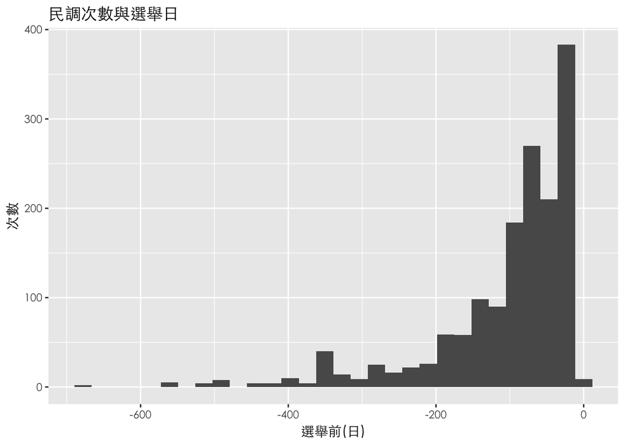

```r
ggplot(data = dtSample, aes(x = preDate)) +
  geom_histogram() + xlab("選舉前(日)") + ylab("次數") + ggtitle("民調次數與選舉日")+
    theme(text = element_text(family = "Heiti TC Light"))
```

```r
dtSample <- dtSample[preDate <= -10 & preDate >= -366]
```

最後剩下的樣本百分比：

```r
dtSample[,.N]/dt[,.N]
```

```
## [1] 0.783264
```

## 假設真實的支持度在民調的過程中沒有變化

### 民調越靠近選舉越準嗎？

我先將選舉前每週與每月加總：

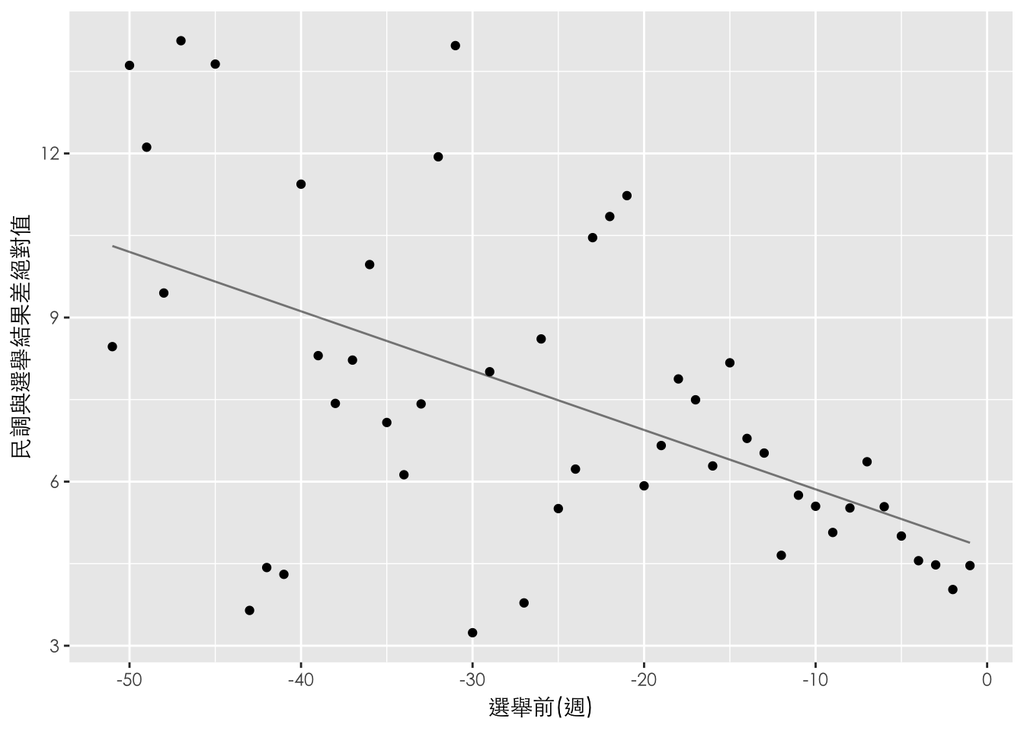

```r
dtSample[,preWeek := ceiling(preDate/7)]
ggplot(data = dtSample[,mean(abs(Error)), by = preWeek],
       aes(x = preWeek, y = V1 ))+ geom_line(stat="smooth",method = "lm",
             alpha = 0.5)+ geom_point() +
       xlab("選舉前(週)") + ylab("民調與選舉結果差絕對值") +
       theme(text = element_text(family = "Heiti TC Light"))
```

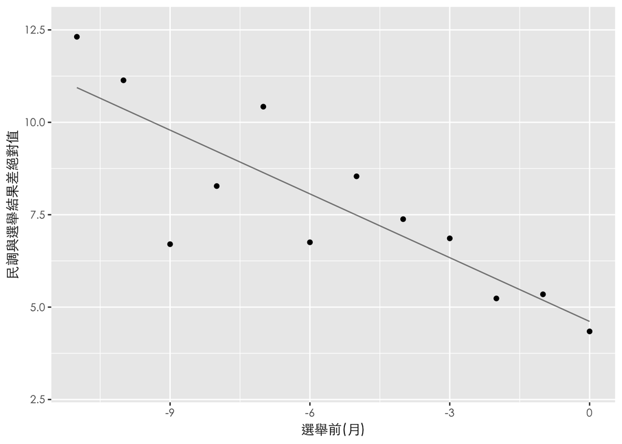

```r
dtSample[,preMonth := ceiling(preDate/30)]
ggplot(data = dtSample[,mean(abs(Error)), by = preMonth],
       aes(x = preMonth, y = V1 )) + geom_line(stat="smooth",method = "lm",
             alpha = 0.5)+ geom_point()+
       xlab("選舉前(月)") + ylab("民調與選舉結果差絕對值") +
       theme(text = element_text(family = "Heiti TC Light"))
```

兩大黨哪個的民調比較難猜？

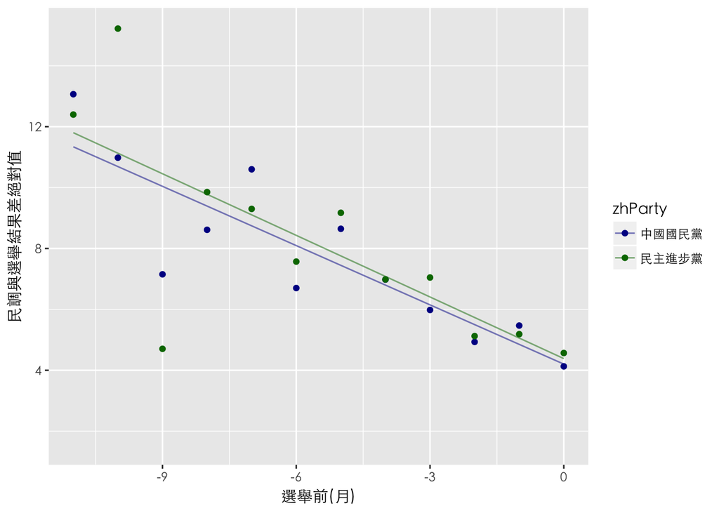

```r
group.colors <- c("民主進步黨" = "#007500", "中國國民黨" = "#000093")

ggplot(data = dtSample[zhParty %in% c("民主進步黨","中國國民黨"),mean(abs(Error)), by = c("preMonth","zhParty")],
       aes(x = preMonth, y = V1 , color = zhParty)) + geom_line(stat="smooth",method = "lm",
             alpha = 0.5)+ geom_point()+
       xlab("選舉前(月)") + ylab("民調與選舉結果差絕對值") +
       theme(text = element_text(family = "Heiti TC Light")) +
    scale_color_manual(values=group.colors)
```

```r
pander(lm(data = dtSample[zhParty %in% c("民主進步黨","中國國民黨")],
   formula = I(abs(Error)) ~ zhParty),caption = "誤差民進黨與國民黨無顯著差異",
   add.significance.stars = TRUE)
```

誤差民進黨與國民黨無顯著差異

|  | Estimate | Std. Error | t value | Pr(>\|t\|) |  |
| --- | --- | --- | --- | --- | --- |
| **(Intercept)** | 6.043 | 0.202 | 29.91 | 2.033e-145 | * * * |
| **zhParty民主進步黨** | 0.09565 | 0.2937 | 0.3257 | 0.7447 |  |

```r
dtSample[,underPredicted := (Error > 0)]
pander(lm(data = dtSample[zhParty %in% c("民主進步黨","中國國民黨")],
   formula = underPredicted ~ zhParty),caption = '民進黨民調被低估的其實比較少',
   add.significance.stars = TRUE)
```

民進黨民調被低估的其實比較少

|  | Estimate | Std. Error | t value | Pr(>\|t\|) |  |
| --- | --- | --- | --- | --- | --- |
| **(Intercept)** | 0.7028 | 0.01923 | 36.54 | 6.789e-194 | * * * |
| **zhParty民主進步黨** | -0.08016 | 0.02796 | -2.867 | 0.004222 | * * |